# Course Project - Practical Machine Learning

Christopher Hardison

September 8, 2016

## Introduction

In this project we will be examining measurements from accelerometers worn by test subjects to detect if they are preforming exercises in one of five different ways. More information on the data we will be using can be found at http://groupware.les.inf.puc-rio.br/har in the section on the Weight Lifting Exercise Dataset.

The training data for this project is available here:

https://d396qusza40orc.cloudfront.net/predmachlearn/pml-training.csv

The test data is available here:

https://d396qusza40orc.cloudfront.net/predmachlearn/pml-testing.csv

## Data

First we will load all external libraries we will need.

```r
library(caret)
library(rpart)
library(rpart.plot)
library(rattle)
```

Then we will read in the testing and validation data.

```r
training_set <- read.csv("pml-training.csv", stringsAsFactors = FALSE, header = TRUE)
validation_set <- read.csv("pml-testing.csv", stringsAsFactors = FALSE, header = TRUE)
```

### Cleaning and Preparation

Here we will prepare our training data set by removing fields that don’t help us define our predective model. First lets use the nearZeroVar function to identify columns that have low variance and therefore are not valid predictors.

```r
var_set <- nearZeroVar(training_set)
training_set <- training_set[, -var_set]
```

Second looking at the data we can see we have lot’s of columns were a large number of the values are NA, let’s remove those as well.

```r
NA_set <- sapply(training_set, function(x) mean(is.na(x))) > 0.95
training_set <- training_set[, NA_set==F]
```

Finally let’s remove the first six columns that we can see are obviously not predictors for our models. They contain observations such as timestamps and user information.

```r
training_set <- training_set[, -(1:6)]
```

### Creating Training and Testing Sets

Now that we’ve cleaned the data let’s split it in to separate training and testing sets for our models. We’ll set our training set to be 70% of the testing values and our testing one to be 30%.

```r
set.seed(1776)

training_flag <- createDataPartition(y=training_set$classe, p=0.7, list=FALSE)

training <- training_set[training_flag, ]
testing <- training_set[-training_flag, ]
```

Here’s our training set numbers

```r
dim(training)
```

```
## [1] 13737    53
```

And our testing set numbers.

```r
dim(testing)
```

```
## [1] 5885   53
```

## Model Testing

First we will set up a control for the train function that implements cross validation for our tests.

```r
model_fit_Control <- trainControl(method="cv", number=3, verboseIter = FALSE)
```

### R Part Model

First we will fit an r part model to see how accurately it predicts our data.

```r
rpart_model_fit <- train(classe ~ ., data=training, method="rpart", trControl=model_fit_Control)
```

Here’s the decision tree for our r part model.

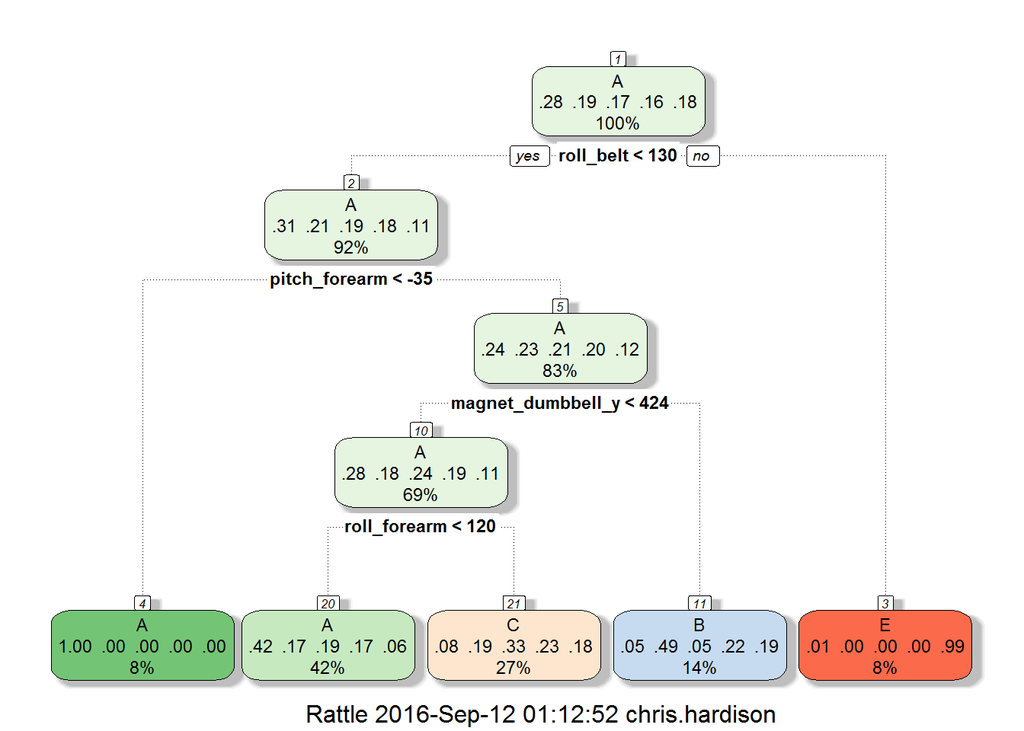

```r
fancyRpartPlot(rpart_model_fit$finalModel)
```

Now we will run our model against our testing set to see what our accuracy is.

```r
rpart_pred <- predict(rpart_model_fit, newdata=testing)
confusionMatrix(testing$classe, rpart_pred)
```

```
## Confusion Matrix and Statistics
##
##           Reference
## Prediction    A    B    C    D    E
##          A 1499   44  126    0    5
##          B  447  400  292    0    0
##          C  463   53  510    0    0
##          D  416  194  354    0    0
##          E  151  173  272    0  486
##
## Overall Statistics
##
##                Accuracy : 0.4919
##                  95% CI : (0.4791, 0.5048)
##     No Information Rate : 0.5057
##     P-Value [Acc > NIR] : 0.9832
##
##                   Kappa : 0.337
##  Mcnemar's Test P-Value : NA
##
## Statistics by Class:
##
##                      Class: A Class: B Class: C Class: D Class: E
## Sensitivity            0.5037  0.46296  0.32819       NA  0.98982
## Specificity            0.9398  0.85282  0.88086   0.8362  0.88951
## Pos Pred Value         0.8955  0.35119  0.49708       NA  0.44917
## Neg Pred Value         0.6493  0.90223  0.78514       NA  0.99896
## Prevalence             0.5057  0.14681  0.26406   0.0000  0.08343
## Detection Rate         0.2547  0.06797  0.08666   0.0000  0.08258
## Detection Prevalence   0.2845  0.19354  0.17434   0.1638  0.18386
## Balanced Accuracy      0.7218  0.65789  0.60452       NA  0.93966
```

We can see from this that our accuracy is very low, 49%, and our out of sample error is very high, 51%.

### GBM Model

Next we will use a GBM Model to see if that preforms better.

```r
gbm_model_fit <- train(classe ~ ., data=training, method="gbm", verbose = FALSE, trControl=model_fit_Control)

gbm_pred <- predict(gbm_model_fit, newdata=testing)

confusionMatrix(testing$classe, gbm_pred)
```

```
## Confusion Matrix and Statistics
##
##           Reference
## Prediction    A    B    C    D    E
##          A 1644   27    3    0    0
##          B   25 1090   23    0    1
##          C    0   41  969   14    2
##          D    0    0   29  920   15
##          E    2   11   10    9 1050
##
## Overall Statistics
##
##                Accuracy : 0.964
##                  95% CI : (0.9589, 0.9686)
##     No Information Rate : 0.2839
##     P-Value [Acc > NIR] : < 2.2e-16
##
##                   Kappa : 0.9544
##  Mcnemar's Test P-Value : NA
##
## Statistics by Class:
##
##                      Class: A Class: B Class: C Class: D Class: E
## Sensitivity            0.9838   0.9324   0.9371   0.9756   0.9831
## Specificity            0.9929   0.9896   0.9882   0.9911   0.9934
## Pos Pred Value         0.9821   0.9570   0.9444   0.9544   0.9704
## Neg Pred Value         0.9936   0.9834   0.9866   0.9953   0.9963
## Prevalence             0.2839   0.1986   0.1757   0.1602   0.1815
## Detection Rate         0.2794   0.1852   0.1647   0.1563   0.1784
## Detection Prevalence   0.2845   0.1935   0.1743   0.1638   0.1839
## Balanced Accuracy      0.9884   0.9610   0.9627   0.9834   0.9883
```

We can see that our accuracy and out of sample error is much better with this model. 96%, and 4% respectivly.

### Random Forest

We’ll try one more model, a random forest, to see if it gives us a better result.

```r
rf_model_fit <- train(classe ~ ., data=training, method="rf", trControl=model_fit_Control)

rf_pred <- predict(rf_model_fit, newdata=testing)

confusionMatrix(testing$classe, rf_pred)
```

```
## Confusion Matrix and Statistics
##
##           Reference
## Prediction    A    B    C    D    E
##          A 1673    1    0    0    0
##          B    3 1136    0    0    0
##          C    0    1 1022    3    0
##          D    0    0    8  955    1
##          E    0    1    5    1 1075
##
## Overall Statistics
##
##                Accuracy : 0.9959
##                  95% CI : (0.9939, 0.9974)
##     No Information Rate : 0.2848
##     P-Value [Acc > NIR] : < 2.2e-16
##
##                   Kappa : 0.9948
##  Mcnemar's Test P-Value : NA
##
## Statistics by Class:
##
##                      Class: A Class: B Class: C Class: D Class: E
## Sensitivity            0.9982   0.9974   0.9874   0.9958   0.9991
## Specificity            0.9998   0.9994   0.9992   0.9982   0.9985
## Pos Pred Value         0.9994   0.9974   0.9961   0.9907   0.9935
## Neg Pred Value         0.9993   0.9994   0.9973   0.9992   0.9998
## Prevalence             0.2848   0.1935   0.1759   0.1630   0.1828
## Detection Rate         0.2843   0.1930   0.1737   0.1623   0.1827
## Detection Prevalence   0.2845   0.1935   0.1743   0.1638   0.1839
## Balanced Accuracy      0.9990   0.9984   0.9933   0.9970   0.9988
```

That’s the best we have seen 99.6% accuracy and .4% out of sample error.

## Conclusion

The Random Forest model gives us our best accuracy so we will use that on our validation set to predict the values for the 20 different cases.

```r
predict(rf_model_fit, newdata=validation_set)
```

```
##  [1] B A B A A E D B A A B C B A E E A B B B
## Levels: A B C D E
```